# Probabilidad basica

Emiliano Villicaña

3/2/2020

## Probabilidad básica.

En este Markdown haremos un repaso de la probabilidad básica de R. Está pensado para que el usuario se familiarice con los métodos más básicos.

# Probabilidad con dados

Un ejemplo básico es el resultado de un dado donde el espacio de posibles casos es **{1,2,3,4,5,6}**

```r
sample(1:6, 1)
```

```
## [1] 2
```

Cada vez que ejecutemos el código dará un número diferente y cada número tiene la misma probabilidad de ser sacado.

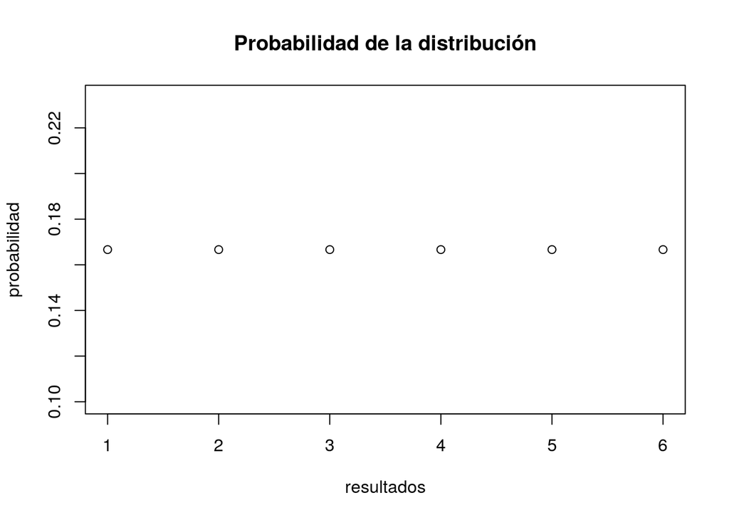

```r
# Genera el vector de probabilidades
probabilidad <- rep(1/6, 6)

# Gráfica simple de probabilidad
plot(probabilidad,
     main = "Probabilidad de la distribución",
     xlab = "resultados")
```

Cada evento tiene 1/6 o 16% de ser sacado.

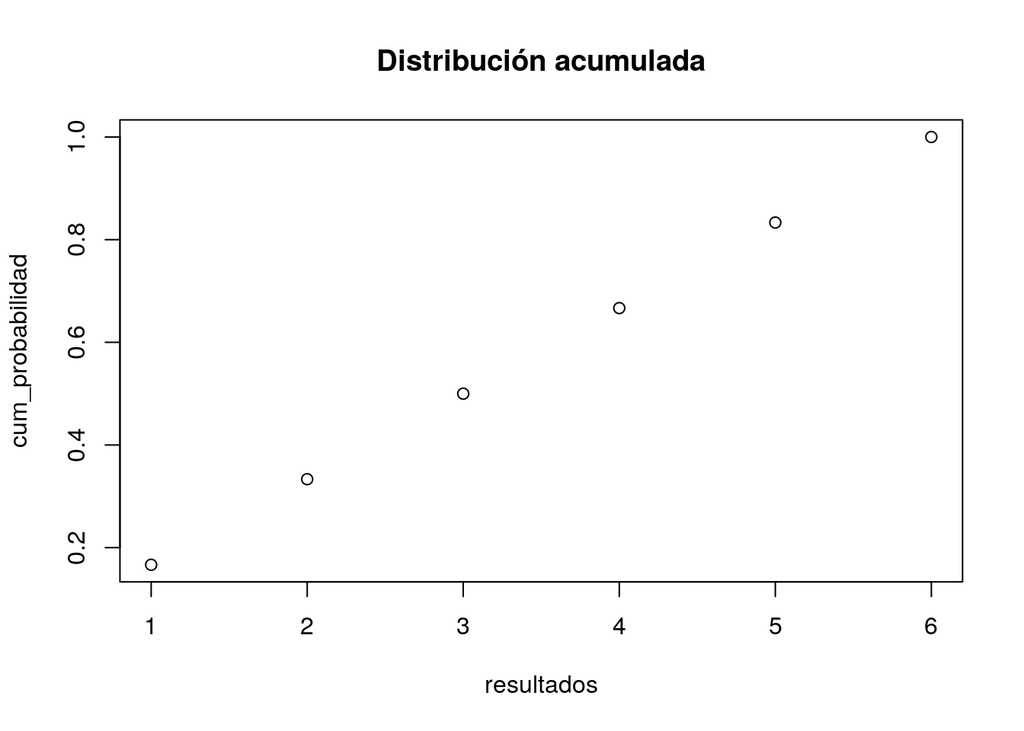

```r
# Vector de probabilidad acumulada
cum_probabilidad <- cumsum(probabilidad)

# gráfica
plot(cum_probabilidad,
     xlab = "resultados",
     main = "Distribución acumulada")
```

# Volado

Otro ejercicio clásico es el de lanzar una moneda. Tienes 2 resultados posibles “Águila”(A) o “Sol”(S)

```r
sample(c("A", "S"), 1)
```

```
## [1] "S"
```

Sample toma una muestra que puede ser con y sin reemplazo, lo cual significa que si sale sol una vez, solamente puede salir águila en el siguiente volado. Intenta cambiar el número por 2 y 3.

Esta es una distribución de Bernoulli. la probabilidad está dada por

$$f(k)=P(k)=\begin{pmatrix}n\\ k \end{pmatrix} \cdot p^k \cdot
(1-p)^{n-k}=\frac{n!}{k!(n-k)!} \cdot p^k \cdot (1-p)^{n-k}$$

En R podemos utilizar >dbinom() que calcula la probabilidad $P(k|n, p)$ esto es la probabilidad de la distribución binomial dado los parámetros x (k), tamaño(n), y prob(p), utilizando esto calculamos la $P(k=5\vert n = 10, p = 0.5)$

```r
dbinom( x = 5,
        size = 10,
        prob = 0.5)
```

```
## [1] 0.2460938
```

Lo que todo esto significa es que la probabilidad de sacar 5 soles o águilas en 10 volados es de 24.6%

Ahora vamos a observar la $P(4 \leq k \leq 7)$

```r
sum(dbinom(x = 4:7, size = 10, prob = 0.5))
```

```
## [1] 0.7734375
```

Alrededor del 77% de que tengamos 4,5,6 o 7 “éxitos” es decir que salga águila.

La distribución de probabilidad de una variable discreta no es más que un conjunto de posibles resultados que pueden ocurrir con una respectiva probabilidad. Regresando al ejemplo

```r
# Posibles resultados
k <- 0:10
```

Vamos a ver la distribución.

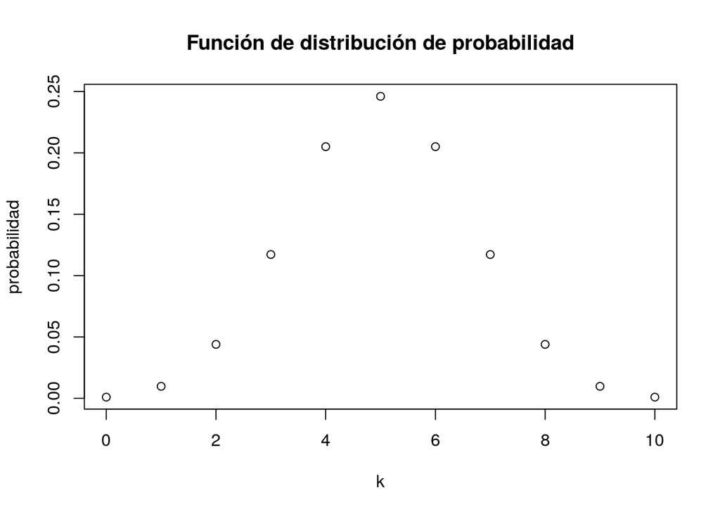

```r
# Asignamos la probabilidad
probabilidad <- dbinom(x = k,
                      size = 10,
                      prob = 0.5)

# plot the outcomes against their probabilities
plot(x = k,
     y = probabilidad,
     main = "Función de distribución de probabilidad")
```

Veamos la probabilidad observada acumulada

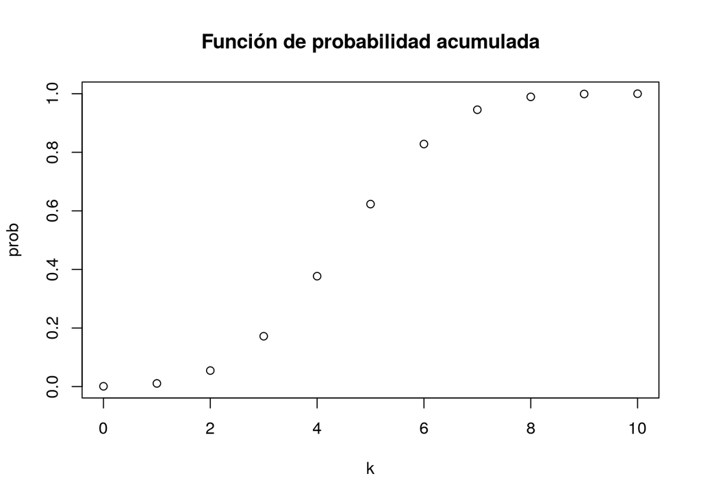

```r
# Probabilidad acumulada
prob <- pbinom(q = k,
               size = 10,
               prob = 0.5)

# Gráfica
plot(x = k,
     y = prob,
     main = "Función de probabilidad acumulada")
```